# MTH6139 Time Series

Coursework 1 – FTSE 100 time series forecasting

Zechen Liu

Spring term 2025

# 1. Introductory

The FTSE 100 (Financial Times Stock Exchange 100 Index) is a key benchmark of the London Stock Exchange (LSE), representing the 100 largest publicly traded companies in the UK by market capitalization.In this project, we apply Meta’s Prophet forecasting model to predict future trends of the FTSE 100 index.The objectives of this study are:  
1. Explore the historical trends of the FTSE 100 index using time series decomposition.  
2. Build a forecasting model using the Prophet library in R.  
3. Evaluate the model’s predictive accuracy by comparing it with actual market movements.  
4. Interpret key trends and seasonality components, such as daily, weekly, and yearly cycles.

[figure not shown]

# 2. Data import and preprocessing

## 2.1 Load R packages

The following R packages are required for analysis:

```r
library(prophet) # Time series forecasting
```

```r
library(ggplot2) # Data visualisation
library(dplyr) # Data processing
library(zoo) # time series processiong
```

## 2.2 Data loading

```r
# Load data
FTSE_100_Stock <- read.csv("data/FTSE_100_Historical_Data_20_24.csv")

# Check the dataset
head(FTSE_100_Stock)
```

```
##         Date    Price     Open     High      Low    Vol. Change..
## 1 12/31/2024 8,173.02 8,121.01 8,180.38 8,096.65 203.36M    0.64%
## 2 12/30/2024 8,121.01 8,149.78 8,149.78 8,094.88 325.04M   -0.35%
## 3 12/27/2024 8,149.78 8,136.99 8,151.28 8,112.29 327.26M    0.16%
## 4 12/24/2024 8,136.99 8,102.72 8,152.01 8,102.72 243.25M    0.42%
## 5 12/23/2024 8,102.72 8,084.61 8,111.41 8,051.92 573.77M    0.22%
## 6 12/20/2024 8,084.61 8,105.32 8,105.83 8,002.34   1.58B   -0.26%
```

```r
# Validates and converts dates
FTSE_100_Stock$Date <- as.Date(FTSE_100_Stock$Date, format = "%m/%d/%Y")

# Convert to dataframe
FTSE_100_df <- data.frame(ds = FTSE_100_Stock$Date, y = FTSE_100_Stock$Price)  # Closing price as y

# Check missing values
sum(is.na(FTSE_100_Stock$y))  # Count missing values
```

```
## [1] 0
```

```r
sum(is.na(FTSE_100_Stock$ds))  # Count missing dates
```

```
## [1] 0
```

```r
# Convert y column to numeric (removing commas)
FTSE_100_df$y <- as.numeric(gsub(",", "", FTSE_100_df$y))

# Check the data
str(FTSE_100_df)
```

```
## 'data.frame':    1262 obs. of  2 variables:
##  $ ds: Date, format: "2024-12-31" "2024-12-30" ...
##  $ y : num  8173 8121 8150 8137 8103 ...
```

```r
head(FTSE_100_df)
```

```
##           ds       y
## 1 2024-12-31 8173.02
## 2 2024-12-30 8121.01
## 3 2024-12-27 8149.78
## 4 2024-12-24 8136.99
## 5 2024-12-23 8102.72
## 6 2024-12-20 8084.61
```

# 3. Data Exploration

## 3.1 Plot FTSE 100 Historical Trends

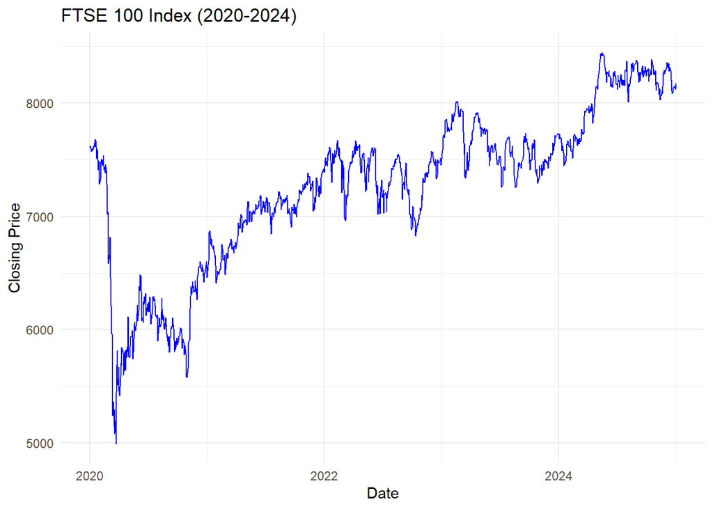

```r
ggplot2::ggplot(FTSE_100_df, aes(x = ds, y = y)) +
  ggplot2::geom_line(color = "blue") +
  ggplot2::labs(title = "FTSE 100 Index (2020-2024)", x = "Date", y = "Closing Price") +
  ggplot2::theme_minimal()
```

## 3.2 Analysis about the historical data

There is a large drop(known as 2020 stock market crash) and then a recovery during 2020, I believe this is because of the Covid-19, and I will discard the data in 2020, so that the Prophet forecasting model will discard the influence of covid-19 and may give a more accurate prediction.

## 3.3 Edit the dataframe and do the plot again

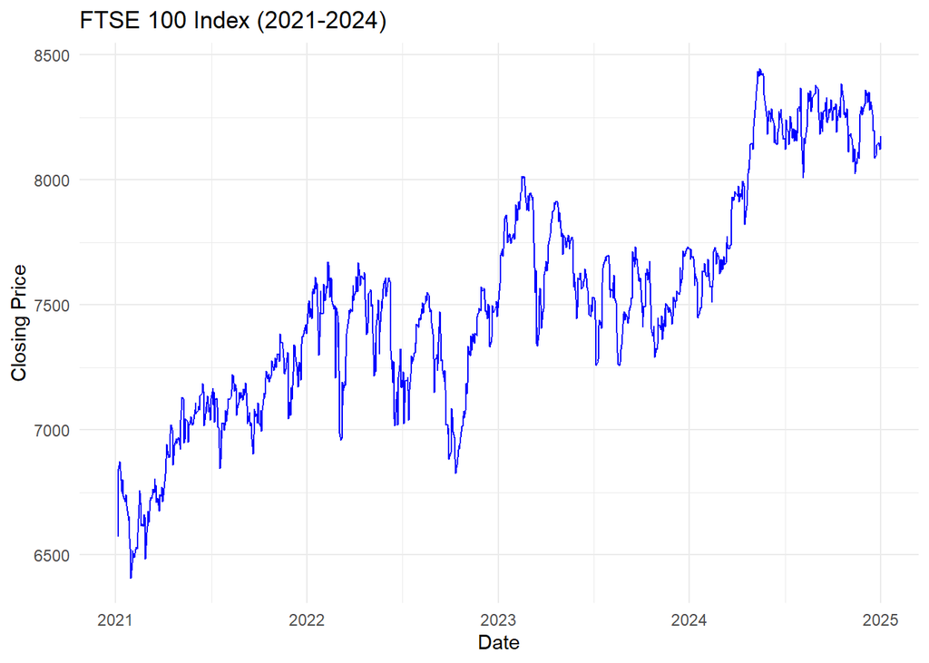

```r
# Discard the 2020 data
FTSE_100_df <- FTSE_100_df %>% dplyr::filter(ds >= as.Date("2021-01-01"))


# Plot FTSE 100 historical trends
ggplot2::ggplot(FTSE_100_df, aes(x = ds, y = y)) +
  ggplot2::geom_line(color = "blue") +
  ggplot2::labs(title = "FTSE 100 Index (2021-2024)", x = "Date", y = "Closing Price") +
  ggplot2::theme_minimal()
```

## 3.4 Calculate basic statistics

```r
FTSE_100_df %>% dplyr::summarise(
  min = min(y, na.rm = TRUE),
  q25 = quantile(y, 0.25, na.rm = TRUE),
  median = median(y, na.rm = TRUE),
  mean = mean(y, na.rm = TRUE),
  q75 = quantile(y, 0.75, na.rm = TRUE),
  max = max(y, na.rm = TRUE),
  sd = sd(y, na.rm = TRUE),
  var = var(y, na.rm = TRUE),
)
```

```
##       min     q25  median    mean     q75    max       sd      var
## 1 6407.46 7187.39 7493.79 7514.05 7766.51 8445.8 451.3234 203692.8
```

# 4. Prophet model predictions

## 4.1 Modelling and Forecasting

```r
# Training
Mymodel <- prophet::prophet(FTSE_100_df)
```

```
## Disabling daily seasonality. Run prophet with daily.seasonality=TRUE to override this.
```

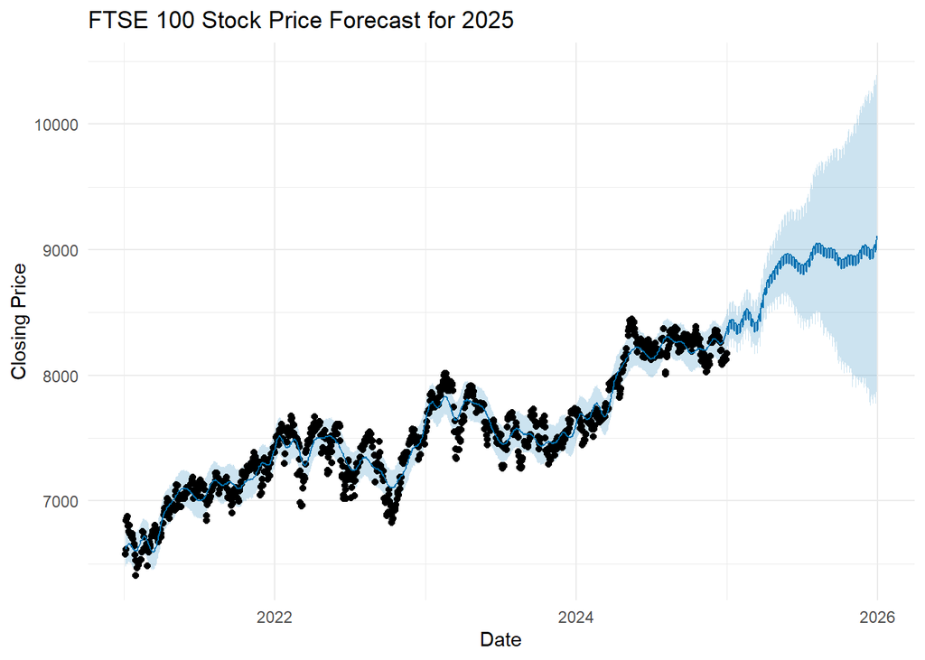

```r
# Generate data for the next year
Future <- prophet::make_future_dataframe(Mymodel, periods = 365, freq = "day")
Forecast <- predict(Mymodel, Future)

# Plotting forecast results
plot(Mymodel, Forecast) +
    ggplot2::ggtitle("FTSE 100 Stock Price Forecast for 2025") +
    ggplot2::labs(x = "Date", y = "Closing Price") +
    ggplot2::theme_minimal()
```

How to understand the forecast plot:  
1. The black dots represent actual FTSE 100 historical prices.  
2. The blue line represents the predicted trend for 2025.  
3. The shaded blue area is the uncertainty interval (confidence interval).  
For point 3, this is a feature that the latest release by Meta does but not the common installed prophet package gives

Forecast Highlights:  
1. The model predicts a general upward movement in the FTSE 100 index in 2025.  
2. The FTSE 100 is forecasted to move above 9000 points by the end of 2025.  
3. The forecast shows wider confidence intervals as we move further into the future. This suggests higher uncertainty, which is common in financial markets.

## 4.2 Plot forecast components (trend & seasonality)

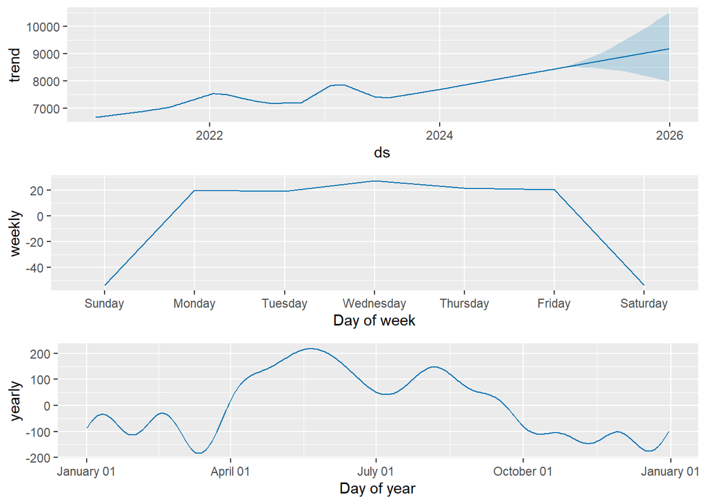

```r
prophet::prophet_plot_components(Mymodel, Forecast)
```

Understand and analyse this plot:  
Plot 1: Trend Component:  
The trend line shows a steady upward movement in the FTSE 100 index. The long-term trend is bullish. The blue shaded region represents the uncertainty interval, which widens in 2025 and beyond, indicating higher prediction uncertainty over time.

Plot 2: Weekly Seasonality:  
The plot shows how the FTSE 100 typically behaves across the days of the week. From Monday to Friday, there is a Slightly positive or stable performance. And there is sharp-drop on Saturday, this is because the FTSE 100 does not trade on weekends, so Prophet assigns a negative seasonality effect. On Sunday, there is an extreme negative effect, but this is a technical issue since the stock market is closed. However, Since trading does not occur on weekends, the Saturday and Sunday effects are artifacts and should be ignored.

# 5. Compare actual vs. predicted

## 5.1 Load the data of 2025

```r
# Load data
FTSE_100_Stock_25 <- read.csv("data/FTSE_100_Historical_Data_25.csv")

# Check the dataset
head(FTSE_100_Stock_25)
```

```
##         Date    Price     Open     High      Low    Vol. Change..
## 1 03/14/2025 8,632.33 8,542.56 8,642.79 8,538.07 750.19M    1.05%
## 2 03/13/2025 8,542.56 8,540.97 8,581.57 8,513.65 767.96M    0.02%
## 3 03/12/2025 8,540.97 8,495.99 8,565.45 8,495.99 974.80M    0.53%
## 4 03/11/2025 8,495.99 8,600.22 8,603.93 8,481.11   1.04B   -1.21%
## 5 03/10/2025 8,600.22 8,679.88 8,700.79 8,591.58   1.52B   -0.92%
## 6 03/07/2025 8,679.88 8,682.84 8,701.31 8,627.30 900.63M   -0.03%
```

```r
# Validates and converts dates
FTSE_100_Stock_25$Date <- as.Date(FTSE_100_Stock_25$Date, format = "%m/%d/%Y")

# Convert to dataframe
FTSE_100_df_25 <- data.frame(ds = FTSE_100_Stock_25$Date, y = FTSE_100_Stock_25$Price)  # Closing price as y

# Check missing values
sum(is.na(FTSE_100_Stock_25$y))  # Count missing values
```

```
## [1] 0
```

```r
sum(is.na(FTSE_100_Stock_25$ds))  # Count missing dates
```

```
## [1] 0
```

```r
# Convert y column to numeric (removing commas)
FTSE_100_df_25$y <- as.numeric(gsub(",", "", FTSE_100_df_25$y))

# Check the data
str(FTSE_100_df_25)
```

```
## 'data.frame':    52 obs. of  2 variables:
##  $ ds: Date, format: "2025-03-14" "2025-03-13" ...
##  $ y : num  8632 8543 8541 8496 8600 ...
```

```r
head(FTSE_100_df_25)
```

```
##           ds       y
## 1 2025-03-14 8632.33
## 2 2025-03-13 8542.56
## 3 2025-03-12 8540.97
## 4 2025-03-11 8495.99
## 5 2025-03-10 8600.22
## 6 2025-03-07 8679.88
```

## 5.2 Plot and compare actual data with predicted data

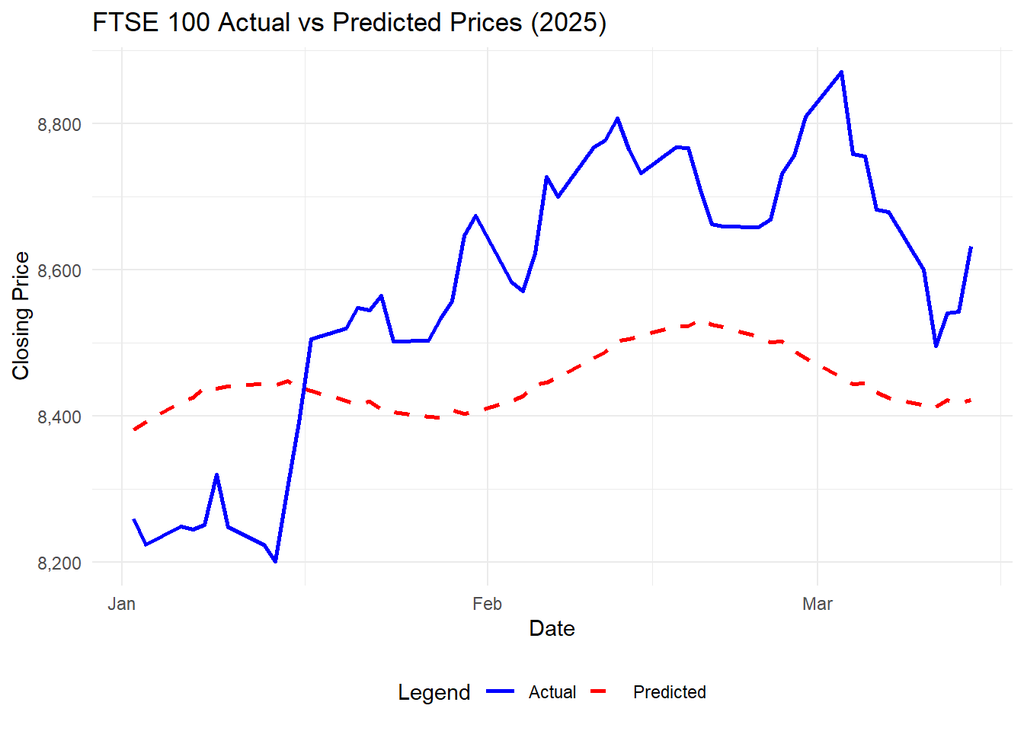

```r
Forecast$ds <- as.Date(Forecast$ds)  # Convert to Date format


# Merge actual and predicted data
Comparison_df <- left_join(FTSE_100_df_25, Forecast, by = "ds")


ggplot(Comparison_df, aes(x = ds)) +
  geom_line(aes(y = y, color = "Actual"), linewidth = 1, linetype = "solid") +  # Actual data
  geom_line(aes(y = yhat, color = "Predicted"), linewidth = 1, linetype = "dashed") +  # Forecasted data
  labs(title = "FTSE 100 Actual vs Predicted Prices (2025)",
       x = "Date", y = "Closing Price", color = "Legend") +  # Legend title
  scale_y_continuous(labels = scales::comma) +
  scale_color_manual(name = "Legend", values = c("Actual" = "blue", "Predicted" = "red")) +  # Custom legend
  theme_minimal() +
  theme(legend.position = "bottom")
```

The forecast captures some seasonality.The dashed red line (forecasted) shows a smooth cyclical movement, suggesting Prophet has detected some seasonal variations. The forecasted prices remain in a reasonable range (8400 - 8500) and don’t produce unrealistic spikes. Also, the forecasted shows an upward trend, which fits the real data.

However, the forecast underestimates market volatility. The actual prices (solid blue line) fluctuate significantly, whereas the forecast is too smooth. This suggests that the model is not capturing short-term price movements or market shocks. Also, the forecasted is significantly below actual prices. The actual FTSE 100 prices are trending higher (~8,600+), while the forecast stays below 8500. This means the model might be biased downward and missing key economic trends.

# 6. Log transformation

## 6.1 Check if it needs log transformation

From the above result, the log transfromation seems not needed, because the forecast underestimates market volatility. Let’s check mathamatically.

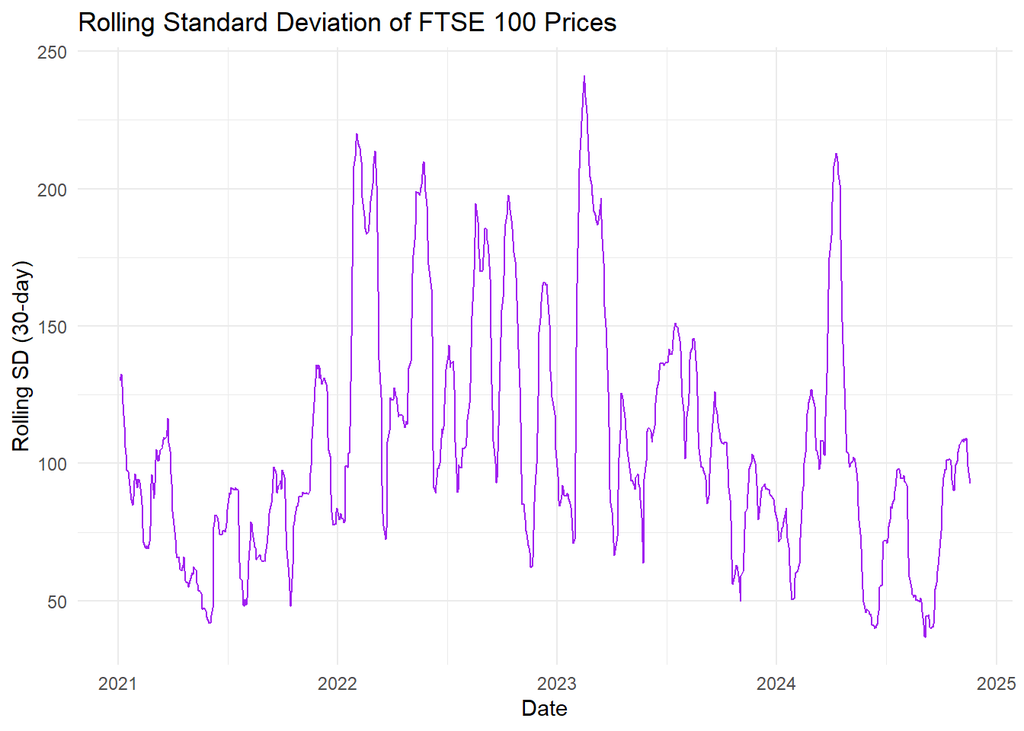

```r
# Compute rolling standard deviation
FTSE_100_df <- FTSE_100_df %>%
    mutate(rolling_sd = rollapply(y, width = 30, FUN = sd, fill = NA, align = "right"))

# Remove NA values before plotting
FTSE_100_df <- na.omit(FTSE_100_df)

# Plot standard deviation over time
ggplot(FTSE_100_df, aes(x = ds, y = rolling_sd)) +
    geom_line(color = "purple") +
    labs(title = "Rolling Standard Deviation of FTSE 100 Prices",
         x = "Date", y = "Rolling SD (30-day)") +
    theme_minimal()
```

From the plot, the rolling standard deviation does not increase over time, i.e. the variance is not increasing over time. Log transformation is no needed.

## 6.2 Prove the result from 6.1 by doing log transformation

```r
# take logs of the price
FTSE_100_df$y_log <- log(FTSE_100_df$y)

# Prepare Prophet model using log-transformed data
df_log <- FTSE_100_df %>% select(ds, y_log)
colnames(df_log) <- c("ds", "y")

# Training the model
Mymodel_log <- prophet(df_log)
```

```
## Disabling daily seasonality. Run prophet with daily.seasonality=TRUE to override this.
```

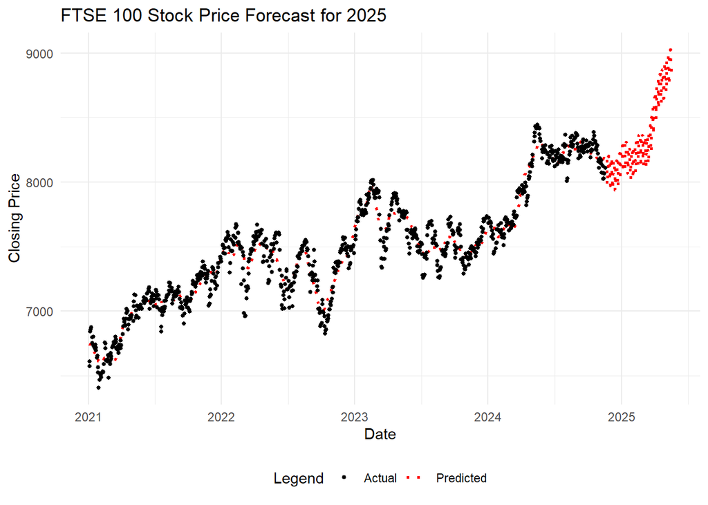

```r
# Generate future dates
Future_log <- make_future_dataframe(Mymodel_log, periods = 180, freq = "day")

# Forecast using the log-transformed model
Forecast_log <- predict(Mymodel_log, Future_log)

Forecast_log <- Forecast_log %>%
  dplyr::mutate(
    yhat = exp(yhat),
    yhat_lower = exp(yhat_lower),
    yhat_upper = exp(yhat_upper),
    trend_lower = exp(trend_lower),
    trend = exp(trend),
    trend_upper = exp(trend_upper)
  )

# Convert back to original scale
df_log <- df_log %>%
  dplyr::mutate(y= exp(y))

FTSE_100_df$y_log <- exp(FTSE_100_df$y_log)

# Convert date columns to POSIXct format
FTSE_100_df$ds <- as.POSIXct(FTSE_100_df$ds)
Forecast_log$ds <- as.POSIXct(Forecast_log$ds)

# Plot the prediction
ggplot() +
  # Predicted trend line with legend
  geom_line(data = Forecast_log, aes(x = ds, y = yhat, color = "Predicted"), linetype = "dotted", linewidth = 1) +
  # Actual data points with legend
  geom_point(data = FTSE_100_df, aes(x = ds, y = y_log, color = "Actual"), size = 1) +
  labs(title = "FTSE 100 Stock Price Forecast for 2025",
       x = "Date", y = "Closing Price", color = "Legend") +  # Legend title
  scale_color_manual(values = c("Actual" = "black", "Predicted" = "red")) +  # Custom legend colors
  theme_minimal() +
  theme(legend.position = "bottom")  # Move legend to the bottom
```

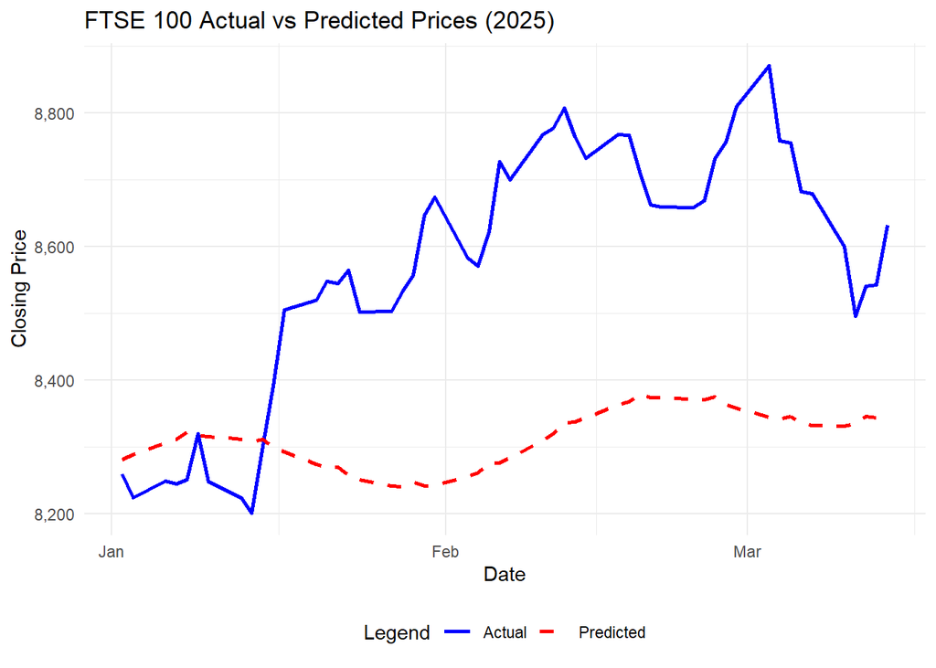

```r
# Compare the actual data and the forecast by log transformation
Forecast_log$ds <- as.Date(Forecast_log$ds)  # Convert to Date format

# Merge actual and predicted data by log transfromation
Comparison_df_log <- left_join(FTSE_100_df_25, Forecast_log, by = "ds")

# Plot the comparision
ggplot(Comparison_df_log, aes(x = ds)) +
  geom_line(aes(y = y, color = "Actual"), linewidth = 1, linetype = "solid") +  # Actual data
  geom_line(aes(y = yhat, color = "Predicted"), linewidth = 1, linetype = "dashed") +  # Forecasted data
  labs(title = "FTSE 100 Actual vs Predicted Prices (2025)",
       x = "Date", y = "Closing Price", color = "Legend") +  # Legend title
  scale_y_continuous(labels = scales::comma) +
  scale_color_manual(name = "Legend", values = c("Actual" = "blue", "Predicted" = "red")) +  # Custom legend
  theme_minimal() +
  theme(legend.position = "bottom")
```

# 7. Mathematical insight

Prophet model formula:

$$y(t) = g(t) + s(t) + h(t) +
\epsilon_t$$
g(t): Trend Component
s(t): Seasonal Component
h(t): Holiday Effects( Accounts for special events (e.g., holidays, financial market crashes).)
epsilon_t: Error Term (Uncertainty)

# 8. Conclusion and outlook

This study analyzed the FTSE 100 index using time series forecasting techniques, particularly the Prophet model. The Prophet model successfully captured the overall trend and seasonal components of the index, providing reasonable future predictions. The comparison between actual and predicted values for early 2025 indicates that while the model follows the general trend, there is a large underestimation of the forecast compared to the actual prices. I may need incorporate external factors like interest rates, oil prices, and economic policy uncertainty to refine the model. Also larger dataset might work as well. Also, the log transfromation is not fitted better in this model.

# 9. References

-Data: https://www.investing.com/indices/uk-100-historical-data  
-RStudio reference: https://rmarkdown.rstudio.com/lesson-1.html  
-Analysis refernce: https://ifs.org.uk/publications/impact-covid-19-share-prices-uk  
https://en.wikipedia.org/wiki/2020_stock_market_crash  
https://www.londonstockexchange.com/discover/news-and-insights/how-londons-dynamic-markets-are-responding-covid-19  
https://www.nasdaq.com/articles/why-april-could-see-the-stock-market-move-even-higher

# 10. GitHub links

[Project GitHub repository](https://github.com/ZechenLiu826/time_series_project)